# Juwon Lee Project 1

2022-04-03

## 1. Introduction

Each year, the NFL releases a list of the “Top 100 Players” of the past season. The list is created through voting by players and players only. As an avid football fan, I wanted to take a look at if the rankings are determined as easily as the players with the best statistics.

Data was collected through a python web scraping script using BS4. Ranking data was collected from https://en.wikipedia.org/wiki/NFL_Top_100 All statistical data was collected from https://www.pro-football-reference.com/players/

Position abbreviations:

- QB = Quarterback
- RB = Running Back
- WR = Wide Receiver
- TE = Tight End
- Playmakers = RB + WR + TE
- OT = Offensive Tackle
- G = Gaurd
- C = Center
- DE = Defenseive End
- DT = Defenseive Tackle
- LB = Linebacker
- S = Safety
- CB = Corner Back
- K = Kicker

Each statistics datasets (ending in _stats) include position specific performace metrics. Quarterbacks track passing stats, playmakers have rushing and receiving stats, and defensive players share all defensive stats (such as tackling, interceptions, etc.)

I expect that the rankings will not follow direct trends with any specific statistic as there is so much more to a player’s performace than what shows up on the statsheet.

## Read in data

```r
# read in data of rankings and statistics
untidy_rankings <- read.csv("./Data/Ranking.csv")
qb_stats <- read.csv("./Data/qb_stats.csv")
rb_stats <- read.csv("./Data/rb_stats.csv")
te_stats <- read.csv("./Data/te_stats.csv")
wr_stats <- read.csv("./Data/wr_stats.csv")
def_stats <- read.csv("./Data/def_stats.csv")

head(untidy_rankings,10) # see first 10 rows of the rankings dataset
```

```
##   X          Player    X2010     X2011     X2012     X2013     X2014    X2015
## 1 1       Tom Brady  1_NE_QB   4_NE_QB   4_NE_QB   3_NE_QB   3_NE_QB  2_NE_QB
## 2 2  Peyton Manning 2_IND_QB 50_IND_QB  2_DEN_QB  1_DEN_QB  5_DEN_QB     <NA>
## 3 3 Adrian Peterson 3_MIN_RB  8_MIN_RB  1_MIN_RB  4_MIN_RB 62_MIN_RB 5_MIN_RB
## 4 4       Ray Lewis 4_BAL_LB 20_BAL_LB      <NA>      <NA>      <NA>     <NA>
## 5 5         Ed Reed  5_BAL_S  16_BAL_S  18_BAL_S      <NA>      <NA>     <NA>
## 6 6   Troy Polamalu  6_PIT_S  19_PIT_S  91_PIT_S  61_PIT_S      <NA>     <NA>
## 7 7   Andre Johnson 7_HOU_WR 15_HOU_WR 14_HOU_WR 21_HOU_WR      <NA>     <NA>
##       X2016   X2017   X2018    X2019   X2020
## 1   1_NE_QB 1_NE_QB 6_NE_QB 14_NE_QB 7_TB_QB
## 2      <NA>    <NA>    <NA>     <NA>    <NA>
## 3 98_MIN_RB    <NA>    <NA>     <NA>    <NA>
## 4      <NA>    <NA>    <NA>     <NA>    <NA>
## 5      <NA>    <NA>    <NA>     <NA>    <NA>
## 6      <NA>    <NA>    <NA>     <NA>    <NA>
## 7      <NA>    <NA>    <NA>     <NA>    <NA>
##  [ reached 'max' / getOption("max.print") -- omitted 3 rows ]
```

This data is not tidy so we need to clean it up

## 2. Tidy + Clean Data

Pivot longer

```r
# Pivot longer to have each row represent an observation
untidy_rankings %>% pivot_longer(cols = c("X2010":"X2020"),
                          names_to = "Year",
                          values_to = "rank_team_pos")
```

```
## # A tibble: 4,741 x 4
##        X Player    Year  rank_team_pos
##    <int> <chr>     <chr> <chr>
##  1     1 Tom Brady X2010 1_NE_QB
##  2     1 Tom Brady X2011 4_NE_QB
##  3     1 Tom Brady X2012 4_NE_QB
##  4     1 Tom Brady X2013 3_NE_QB
##  5     1 Tom Brady X2014 3_NE_QB
##  6     1 Tom Brady X2015 2_NE_QB
##  7     1 Tom Brady X2016 1_NE_QB
##  8     1 Tom Brady X2017 1_NE_QB
##  9     1 Tom Brady X2018 6_NE_QB
## 10     1 Tom Brady X2019 14_NE_QB
## # ... with 4,731 more rows
```

Separate Column

```r
# Separate rank_team_pos into three separate columns
untidy_rankings %>% pivot_longer(cols = c("X2010":"X2020"),
                          names_to = "Year",
                          values_to = "rank_team_pos") %>%
  separate(rank_team_pos, into = (c("Rank","Team","Position")), convert = T)
```

```
## # A tibble: 4,741 x 6
##        X Player    Year   Rank Team  Position
##    <int> <chr>     <chr> <int> <chr> <chr>
##  1     1 Tom Brady X2010     1 NE    QB
##  2     1 Tom Brady X2011     4 NE    QB
##  3     1 Tom Brady X2012     4 NE    QB
##  4     1 Tom Brady X2013     3 NE    QB
##  5     1 Tom Brady X2014     3 NE    QB
##  6     1 Tom Brady X2015     2 NE    QB
##  7     1 Tom Brady X2016     1 NE    QB
##  8     1 Tom Brady X2017     1 NE    QB
##  9     1 Tom Brady X2018     6 NE    QB
## 10     1 Tom Brady X2019    14 NE    QB
## # ... with 4,731 more rows
```

Select and Remove Columns

```r
# Clean Year column, remove unnecessary columns, and drop NA values
untidy_rankings %>% pivot_longer(cols = c("X2010":"X2020"),
                          names_to = "Year",
                          values_to = "rank_team_pos") %>%
  separate(rank_team_pos, into = (c("Rank","Team","Position")), convert = T) %>%
  separate(Year, into = (c("x1","Year")), sep = (1:1), convert = T) %>%
  select(-X, - x1) %>% drop_na()
```

```
## # A tibble: 1,100 x 5
##    Player     Year  Rank Team  Position
##    <chr>     <int> <int> <chr> <chr>
##  1 Tom Brady  2010     1 NE    QB
##  2 Tom Brady  2011     4 NE    QB
##  3 Tom Brady  2012     4 NE    QB
##  4 Tom Brady  2013     3 NE    QB
##  5 Tom Brady  2014     3 NE    QB
##  6 Tom Brady  2015     2 NE    QB
##  7 Tom Brady  2016     1 NE    QB
##  8 Tom Brady  2017     1 NE    QB
##  9 Tom Brady  2018     6 NE    QB
## 10 Tom Brady  2019    14 NE    QB
## # ... with 1,090 more rows
```

Add new Column “Points”, sort, and save

```r
# sort values by Year and rank
# Add new column "Points" as a way to quantify ranking (higher rank equates to more points)
# save to new dataframe: rankings
rankings <- untidy_rankings %>% pivot_longer(cols = c("X2010":"X2020"),
                          names_to = "Year",
                          values_to = "rank_team_pos") %>%
  separate(rank_team_pos, into = (c("Rank","Team","Position")), convert = T) %>%
  separate(Year, into = (c("x1","Year")), sep = (1:1), convert = T) %>%
  select(-X, - x1) %>% drop_na() %>%
  arrange(Year, Rank) %>%
  mutate(Points = 101- Rank)

rankings
```

```
## # A tibble: 1,100 x 6
##    Player           Year  Rank Team  Position Points
##    <chr>           <int> <int> <chr> <chr>     <dbl>
##  1 Tom Brady        2010     1 NE    QB          100
##  2 Peyton Manning   2010     2 IND   QB           99
##  3 Adrian Peterson  2010     3 MIN   RB           98
##  4 Ray Lewis        2010     4 BAL   LB           97
##  5 Ed Reed          2010     5 BAL   S            96
##  6 Troy Polamalu    2010     6 PIT   S            95
##  7 Andre Johnson    2010     7 HOU   WR           94
##  8 Darrelle Revis   2010     8 NYJ   CB           93
##  9 Drew Brees       2010     9 NOR   QB           92
## 10 Julius Peppers   2010    10 CHI   DE           91
## # ... with 1,090 more rows
```

## 3. Join and Merge

Merge WR, RB, and TE statistics into one dataframe: `playmakers`

```r
playmakers <- rbind(rb_stats, wr_stats, te_stats) %>% select(-X)
# We can merge these three together as their attributes/columns are the exact same
playmakers %>% head(10)
```

```
##   Year          Player Rush Rush.Yds Rush.TD Rush.1D Rush.Lng Rush.Y.A Rush.Y.G
## 1 2010 Adrian Peterson  283     1298      12      71       80      4.6     86.5
## 2 2010   Chris Johnson  316     1364      11      57       76      4.3     85.3
## 3 2010    Arian Foster  327     1616      16      90       74      4.9    101.0
##    A.G Tgt Rec Rec.Yds Rec.Y.R Rec.TD Rec.1D Rec.Lng R.G Rec.Y.G     Ctch.
## 1 18.9  50  36     341     9.5      1     17      34 2.4    22.7 0.7200000
## 2 19.8  57  44     245     5.6      1      9      25 2.8    15.3 0.7719298
## 3 20.4  84  66     604     9.2      2     34      50 4.1    37.8 0.7857143
##   Y.Tgt Touch Y.Tch YScm RRTD Fmb AV
## 1   6.8   319   5.1 1639   13   1 11
## 2   4.3   360   4.5 1609   12   3 13
## 3   7.2   393   5.6 2220   18   3 20
##  [ reached 'max' / getOption("max.print") -- omitted 7 rows ]
```

Join Ranking data with stats data for QBs, Playmakers, and Defensive Players based on unique IDs.

```r
# count number of rows of each dataset before joining together
qb_stats %>% nrow()
```

```
## [1] 150
```

```r
playmakers %>% nrow()
```

```
## [1] 355
```

```r
def_stats %>% nrow()
```

```
## [1] 480
```

```r
rankings %>% nrow()
```

```
## [1] 1100
```

Both ranking and statistics data use the player and the year as their unique ID. We will use both to join our data together. We will now be able to see how statistics match up with rankings on the Top 100.

```r
qb_rank_stats <- qb_stats %>% inner_join(rankings, by = c("Player", "Year"))

playmakers_rank_stats <- playmakers %>%
  inner_join(rankings, by = c("Player", "Year"))
# have to add more IDs to join on for playmakers since it's already a merged dataset so they have overlapping columns

def_rank_stats <- def_stats %>% inner_join(rankings, by = c("Player", "Year"))
# We use inner join as we want in the updated dataset only the players that are in both their player statistic and ranking statistic
```

How many rows were dropped?

```r
# count number of rows now with joined data to see how many rows were dropped
qb_rank_stats %>% nrow()
```

```
## [1] 150
```

```r
playmakers_rank_stats %>% nrow()
```

```
## [1] 355
```

```r
def_rank_stats %>% nrow()
```

```
## [1] 480
```

There was a corresponding ranking for each of the statistical row as they didn’t reduce in size of data.

## 4. Wrangling

Create a “Top 10” variable

Holding a ranking in the Top 10 of each year is a coveted achievement. Let’s classify which players are in the Top 10

```r
rankings <- rankings %>%
  mutate(Top_10 = ifelse(Rank <= 10, T, F)) # create new column if rank is less than or equal to 10
rankings %>% head(10)
```

```
## # A tibble: 10 x 7
##    Player           Year  Rank Team  Position Points Top_10
##    <chr>           <int> <int> <chr> <chr>     <dbl> <lgl>
##  1 Tom Brady        2010     1 NE    QB          100 TRUE
##  2 Peyton Manning   2010     2 IND   QB           99 TRUE
##  3 Adrian Peterson  2010     3 MIN   RB           98 TRUE
##  4 Ray Lewis        2010     4 BAL   LB           97 TRUE
##  5 Ed Reed          2010     5 BAL   S            96 TRUE
##  6 Troy Polamalu    2010     6 PIT   S            95 TRUE
##  7 Andre Johnson    2010     7 HOU   WR           94 TRUE
##  8 Darrelle Revis   2010     8 NYJ   CB           93 TRUE
##  9 Drew Brees       2010     9 NOR   QB           92 TRUE
## 10 Julius Peppers   2010    10 CHI   DE           91 TRUE
```

Which players has been ranked in the Top 10 the most times?

```r
rankings %>% group_by(Player) %>% # group by player
  filter(Top_10 == T) %>% # look at only players in the top 10 each year
  summarize(n = n()) %>% # count number of occurrences
  arrange(-n) %>% # sort by n descending
  head(10) %>% # display top 10
  kable("simple") # display through kable
```

| Player | n |
| --- | --- |
| Tom Brady | 10 |
| Aaron Rodgers | 8 |
| Adrian Peterson | 5 |
| Antonio Brown | 5 |
| Drew Brees | 5 |
| Aaron Donald | 4 |
| Calvin Johnson | 4 |
| Julio Jones | 4 |
| Peyton Manning | 4 |
| Von Miller | 4 |

For Quarterbacks in the Top 10, what are their statistics like compared to non Top 10? (Let’s just focus on Yards, Touchdowns, Interceptions, Rate, wins)

```r
qb_metrics <- c("Player", "Year", "Rank", "Team", "Wins", "Yds", "TD", "Int", "Rate")
# vector of specific stats to look at

# recreate qb_Rank_stats with the "Top_10" column
qb_rank_stats <- qb_stats %>%
  inner_join(rankings, by = c("Player", "Year"))

qb_rank_stats %>%
  group_by(Top_10) %>% # group by top 10 vs not
  select(qb_metrics) %>% # select the specific columns
  summarize_all(mean) %>%  # get the average of each column
  summarize_all(diff) %>% # find difference of Top 10 vs non top 10
  kable("simple") # format with kable
```

| Top_10 | Player | Year | Rank | Team | Wins | Yds | TD | Int | Rate |
| --- | --- | --- | --- | --- | --- | --- | --- | --- | --- |
| 1 | NA | 0.2343937 | -44.07678 | NA | 2.878259 | 517.553 | 9.425496 | -2.196604 | 9.363214 |

Quarterbacks that are in the top 10 generally win three more games, throw 500 more yards, 9 more touchdowns, and 2 fewer interceptions.

Let’s do the same for the Playmakers in the Top 10, what are their statistics like compared to non Top 10? (Let’s just focus on Yards, Touchdowns, Interceptions, Rate, wins)

```r
# vector of metrics to look at
playmakers_metrics <- c("Player", "Year", "Team", "Position", "Rank", "Rush",
                        "Rush.Yds", "Rush.TD", "Rec", "Rec.Yds", "Rec.TD",
                        "YScm", "RRTD")

# recreate joined data with "Top 10" column
playmakers_rank_stats <- playmakers_rank_stats %>%
  select(playmakers_metrics) %>%
  mutate(Top_10 = ifelse(Rank <=10, T, F))

playmakers_rank_stats %>%
  select(playmakers_metrics, Top_10) %>% # select metrics columns
  group_by(Top_10) %>% # group by True and False
  summarize_all(mean) %>% # get mean of each column
  summarise_all(diff) # find difference of each column
```

```
## # A tibble: 1 x 14
##   Top_10 Player  Year  Team Position  Rank  Rush Rush.Yds Rush.TD   Rec Rec.Yds
##    <int>  <dbl> <dbl> <dbl>    <dbl> <dbl> <dbl>    <dbl>   <dbl> <dbl>   <dbl>
## 1      1     NA 0.411    NA       NA -47.3  45.2     234.    2.36  11.4    178.
## # ... with 3 more variables: Rec.TD <dbl>, YScm <dbl>, RRTD <dbl>
```

This give us a look at all playmakers, but since each position does focus on different areas, splitting based on specific position would give us a better idea of what makes a “Top 10” player.

```r
# do the same thing as the last code cell but group by position as well
playmakers_rank_stats %>%
  select(playmakers_metrics, Top_10) %>%
  group_by(Position, Top_10) %>% summarize_all(mean) %>%
  summarise_all(diff)
```

```
## # A tibble: 3 x 14
##   Position Top_10 Player  Year  Team  Rank   Rush Rush.Yds Rush.TD   Rec Rec.Yds
##   <chr>     <int>  <dbl> <dbl> <dbl> <dbl>  <dbl>    <dbl>   <dbl> <dbl>   <dbl>
## 1 RB            1     NA 0.220    NA -45.7 65.8     373.    4.30    5.08    63.4
## 2 TE            1     NA 1.73     NA -49.3  0.453     2.66 -0.0943 13.5    322.
## 3 WR            1     NA 0.258    NA -47.3 -1.91    -12.5  -0.0818 21.5    341.
## # ... with 3 more variables: Rec.TD <dbl>, YScm <dbl>, RRTD <dbl>
```

- Running backs in the top 10 average 370+ more rushing yards, 4 touchdowns, and over 50 more receiving yards in total.
- Tight ends in the top 10 average 300+ more receiving yards and almost 4 more touchdowns.
- Wide receivers in the top 10 average 300+ more receiving yards and almost 2 more touchdowns.

What about defensive players?

```r
# add Top 10 column
def_rank_stats <- def_rank_stats %>% mutate(Top_10 = ifelse(Rank <= 10, T, F))

def_rank_stats %>%
  group_by(Position, Top_10) %>%  # group by position and by True and False
  summarize_all(mean) %>% # find mean of each column
  summarize_all(diff) # find difference of each column
```

```
## # A tibble: 5 x 25
##   Position Top_10   Year Player    Int   Yds      TD   Lng      PD     FF
##   <chr>     <int>  <dbl>  <dbl>  <dbl> <dbl>   <dbl> <dbl>   <dbl>  <dbl>
## 1 CB            1 -2.18      NA  0.976 60.3   0.622  26.6   3.32   -0.976
## 2 DE            1 -2.02      NA  0.822 19.2   0.453  19.2   7.19    1.91
## 3 DT            1  1.92      NA -0.143 -1.76 -0.0159 -1.41 -0.244   2.50
## 4 LB            1 -0.361     NA  0.122  1.23  0.192   2.17  0.0970  1.17
## 5 S             1 -5.49      NA  4.46  91.3   0.127  13.9   4.84    0.119
## # ... with 15 more variables: Fmb <dbl>, FR <dbl>, Yds.1 <dbl>, TD.1 <dbl>,
## #   Sk <dbl>, Comb <dbl>, Solo <dbl>, Ast <dbl>, TFL <dbl>, QBHits <dbl>,
## #   Sfty <dbl>, AV <dbl>, Rank <dbl>, Team <dbl>, Points <dbl>
```

- The largest difference in top 10 cornerbacks was interception yards (over 60 more)
- The largest difference in top 10 defensive ends were about 5 more sacks, 20 more tackles, and 13 more QBHits.
- Defensive tackles in the top 10 generally have around 2 more forced fumbles, almost 6 more sacks, and 9 QBHits
- Linebackers in the top 10 generally have 4 more sacks, 12 fewer combined (comb) tackles, and 7 more QBHits
- Safetys in the top 10 generally have 33 fewer combined (comb) tackles, almost 5 more interceptions, and 90 more interception yards

## Visualization I

Which quarterback metric is the most indicative of a players’ ranking? We can first start off by creating a correlation matrix and seeing which chart has the strongest correlation with rank

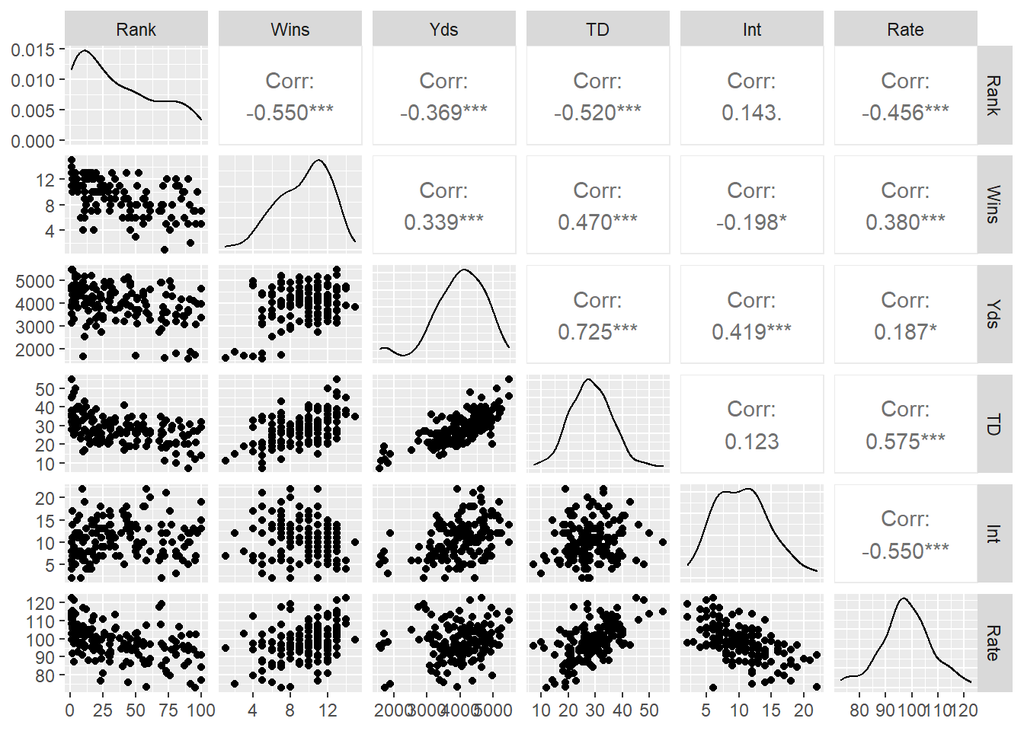

```r
library(GGally)
qb_rank_stats %>%
  select(qb_metrics, -Player, -Team, -Year) %>% # only quantitative variables
  ggpairs() # create correlation matrix
```

Wins has the highest correlation coefficient out of all of the statistics. Touchdowns was the second closest attribute. A plot of Wins against Ranking will be created to better see the relationship.

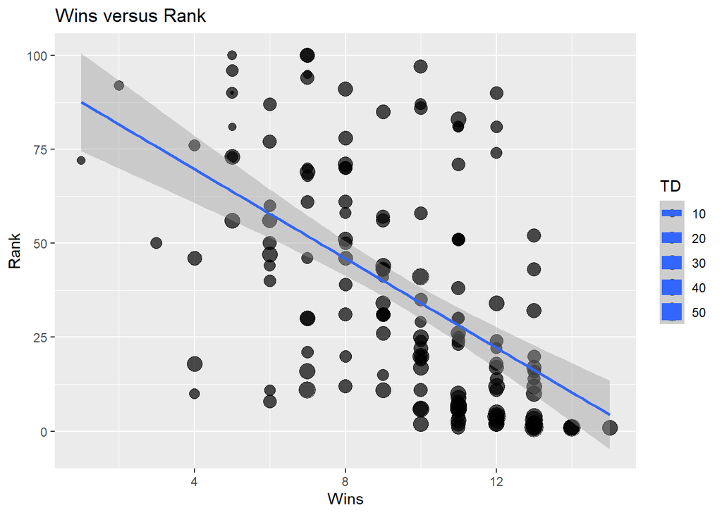

```r
qb_rank_stats %>%
  select(qb_metrics, -Player, -Team) %>% # same selection
  ggplot(aes(x = Wins, y = Rank, size = TD)) + # set variables
  geom_point(alpha = 0.7) + # reduce opacity of points
  geom_smooth(method = "lm") + # add line of best fit
  labs(title = "Wins versus Rank") # add title
```

The relationship isn’t very strong, however, since there is a finite number of wins per season, faceting the graph by year may garner better results

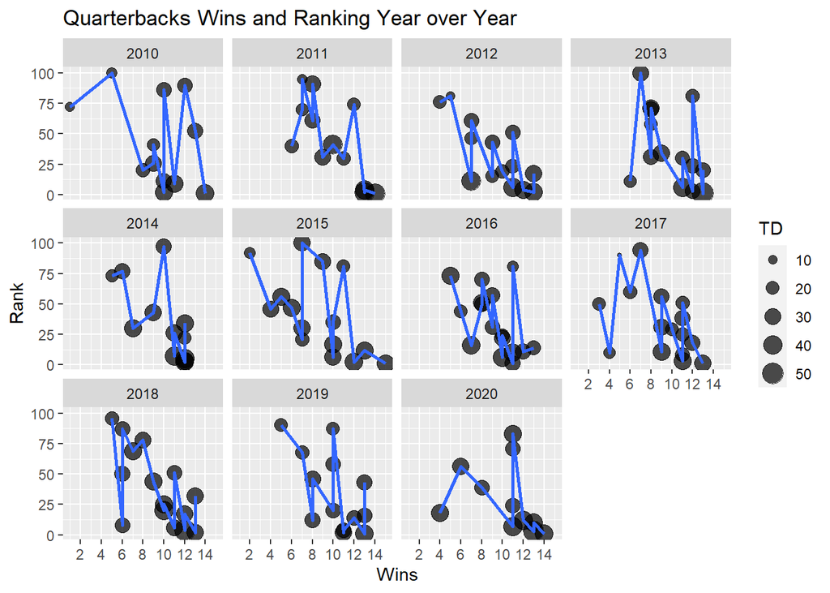

```r
qb_rank_stats %>%
  select(qb_metrics, -Player, -Team) %>% # select same columns
  ggplot(aes(x = Wins, y = Rank, size = TD)) + # set variables
  geom_point(alpha = 0.7) + # reduce opacity
  geom_smooth(stat = "identity", size = 1) + # add connecting line and make thinner
  labs(title = "Quarterbacks Wins and Ranking Year over Year") + # add title
  scale_x_continuous(n.breaks = 8) + # make 8 breaks for x acis
  facet_wrap("Year") # facet by year
```

This visualization shows us that there is more of a correlation between Wins and Ranking for quarterbacks year over year. Winning defines a quarterback’s success, therefore, if a player wins a lot of games (leads the league), they are most likely to be considered the best player in the NFL for that season. While there are certainly some outliers, these can be attributed to a couple of different possibilities. One reason could be that the player did not play in all 16 (now 17) games in the regular season, therefore their total wins was not as high. Overall, a quarterback’s success seems to be heavily ranked by if they are a winner or not.

## Visualization II

Let’s take a look at scrimmage yards (receiving and rushing yards) and if they have any relation to playmakers’ (wide receivers, running backs, and tight ends) ranking.

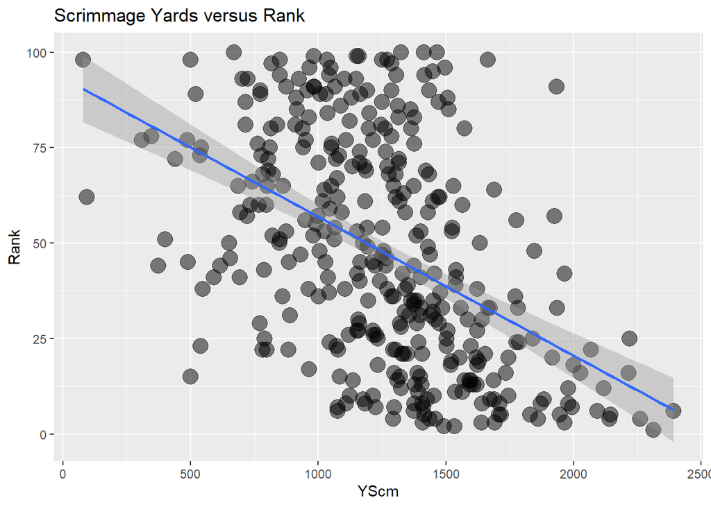

```r
playmakers_rank_stats %>%
  ggplot(aes(x = YScm, y = Rank)) + # set plot variables
  geom_point(alpha = 0.5, size = 5) + # reduce point opacity
  geom_smooth(method = "lm") + # add line of best fit
  labs(title = "Scrimmage Yards versus Rank")
```

There is a weak relationship shown. Separating by position may help us identify a stronger relationship.

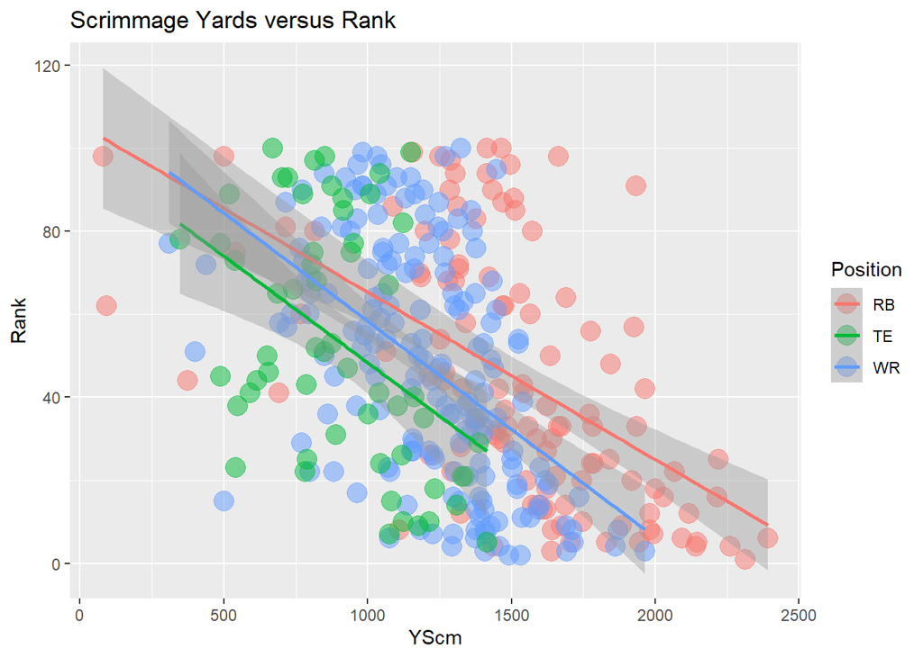

```r
playmakers_rank_stats %>%
  ggplot(aes(x = YScm, y = Rank, color = Position)) + # set color as position
  geom_point(alpha = 0.5, size = 5) + # reduce opacity
  geom_smooth(method = "lm") + # add line of best fit
  labs(title = "Scrimmage Yards versus Rank") # add title
```

There are stronger relationships shown but it is a bit hard to see as the visualization is very busy. Facet this graph to see each graph more clearly. Also add in point size as total touchdowns (RRTD)

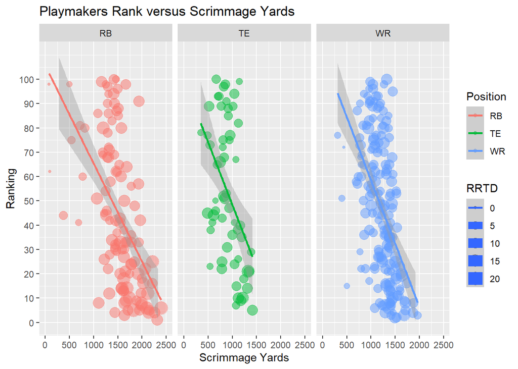

```r
playmakers_rank_stats %>%
  ggplot(aes(x = YScm, y = Rank, color = Position, size = RRTD)) +  # set variables
  geom_point(alpha = 0.5) + # reduce opacity and size
  geom_smooth(method = "lm") + # add line of best fit
  scale_y_continuous(breaks = c(0, 10, 20, 30, 40, 50, 60, 70, 80, 90, 100),#set y axis
                     limits = c(0, 110)) + # set y limits
  scale_x_continuous(n.breaks = 2500/500, limit = c(0, 2500)) + # set x axis and limits
  labs(title = "Playmakers Rank versus Scrimmage Yards", # add title and axis labels
       x = "Scrimmage Yards", y = "Ranking") + facet_wrap("Position")
```

The wide receivers, tight ends, and running backs have different standards when ranking them overall. For example, a player that has 1000 scrimmage yards will be around rank 50 as a tight end, 60 as a wide receiver, and around 65 as a running back. This could be since running backs are typically also catching passes out of the backfield which is an increase in yards. While some wide receivers will also run the ball time to time, it is not a very common occurrence like a running back catching the ball. Tight ends also are blockers on a high percentage of plays which takes away from their chances of catching the ball and gaining more receiving yards. It is also very rare to see a tight end run the ball out of the back field meaning that their scrimmage yards are almost exclusively receiving yards. Additionally, it can be observed that overall, the number of touchdowns that the player scores is a pretty good indicator of their ranking as well.